# Take-Home FInal

Aakash Ahuja

15/12/2019

**Question 1:** Is there a difference in average empathy between the populations of males and females after playing the games? Draw graphs, perform a test, give a confidence interval, and state your conclusion.

**Ans 1:** We can do a 2 sample t-test to test the difference in empathy levels of the 2 genders. Our Null Hypothesis over here is that there is no difference in average empathy levels between the 2 genders.

```r
Game_empathy<-read.table('GameEmpathy.txt', header = T)
summary(Game_empathy)
```

```
##      sex        game.type     identify        empathy
##  female:85   GTA     :48   Min.   :1.000   Min.   :1.714
##  male  :68   HalfLife:55   1st Qu.:3.500   1st Qu.:4.571
##              neutral :50   Median :4.333   Median :5.286
##                            Mean   :4.270   Mean   :5.133
##                            3rd Qu.:5.333   3rd Qu.:5.857
##                            Max.   :7.000   Max.   :7.000
```

```r
str(Game_empathy)
```

```
## 'data.frame':    153 obs. of  4 variables:
##  $ sex      : Factor w/ 2 levels "female","male": 1 1 2 1 1 1 2 1 1 1 ...
##  $ game.type: Factor w/ 3 levels "GTA","HalfLife",..: 3 3 3 3 3 3 3 3 3 3 ...
##  $ identify : num  3.33 1.83 1 1 3.33 ...
##  $ empathy  : num  5.29 5.57 4.71 5.57 3.14 ...
```

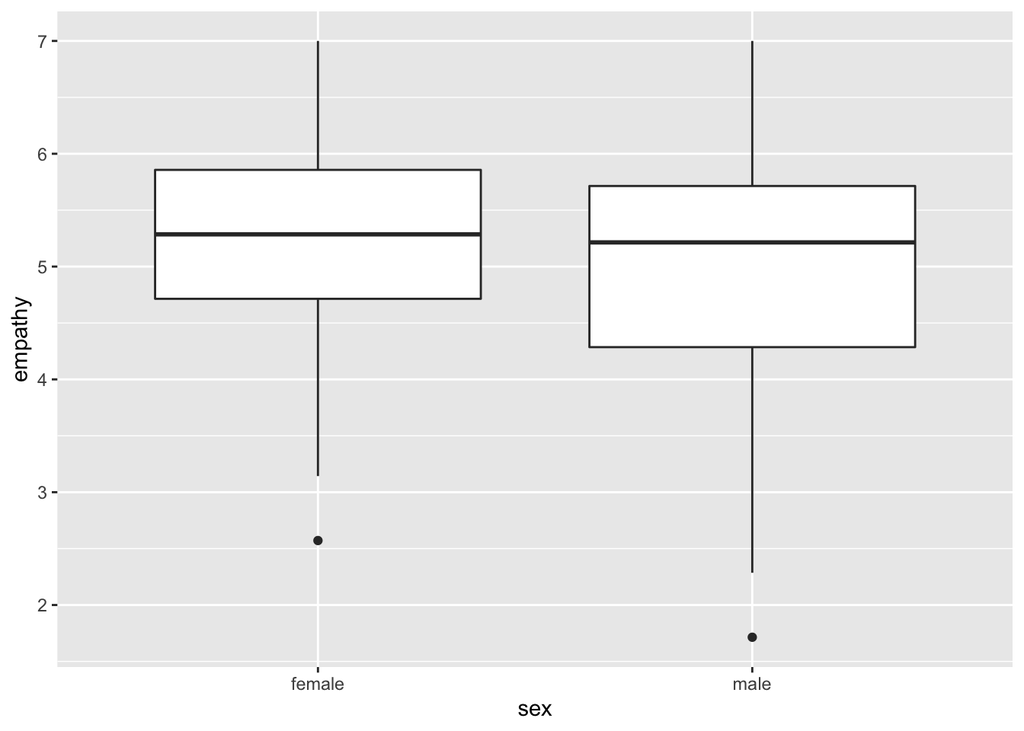

```r
library(ggplot2)
ggplot(Game_empathy,aes(x = sex, y = empathy))+ geom_boxplot()
```

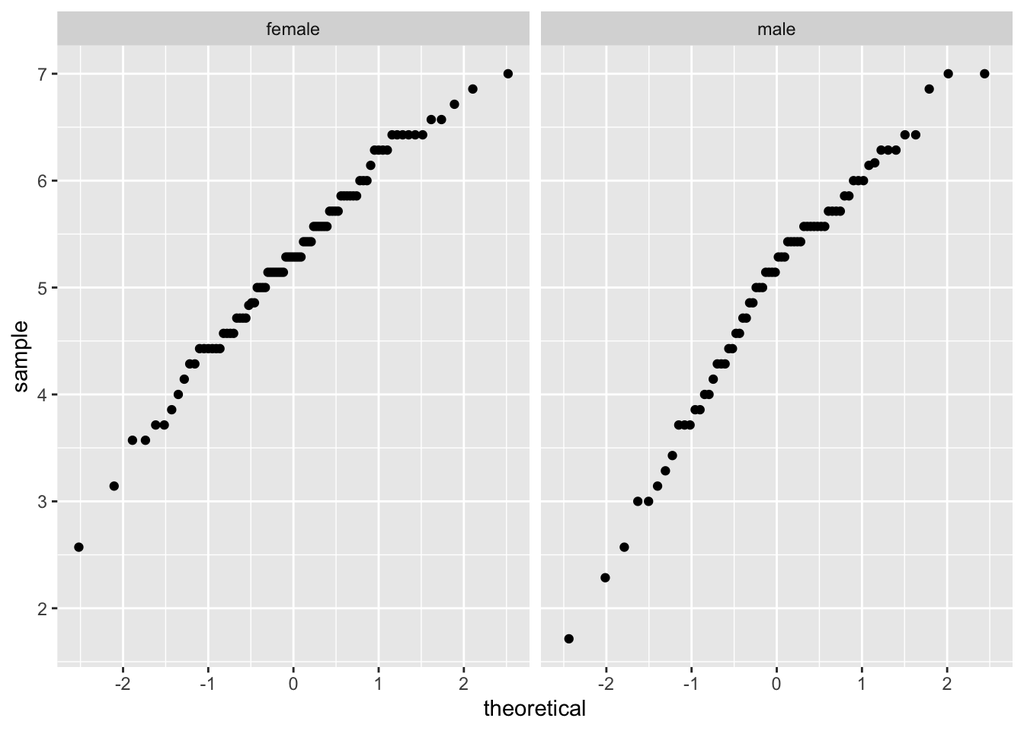

```r
#The average empathy levels do look quite similar.

ggplot(Game_empathy,aes(sample = empathy))+ stat_qq()+ facet_grid(~sex)
```

```r
#It looks like a decent assumption to assume that empathy levels come from a normal distribution for the 2 sexes

# Let's test using Welch's 2 sample T-test
t.test(empathy~sex, data = Game_empathy)
```

```
##
##  Welch Two Sample t-test
##
## data:  empathy by sex
## t = 1.6576, df = 124.65, p-value = 0.09992
## alternative hypothesis: true difference in means is not equal to 0
## 95 percent confidence interval:
##  -0.0542553  0.6134990
## sample estimates:
## mean in group female   mean in group male
##             5.256863             4.977241
```

**Question 2:** Do the different types of game lead to (population) differences in average empathy? Draw graphs, perform an ANOVA, and state your conclusion.

**Ans2:** Due to more than 2 categories present in game.type variable, we’ll do an anova test instead of t-test to test the difference in average empathy levels between various game types. Our Null Hypothesis is that there is no difference in average empathy levels between the various game types.

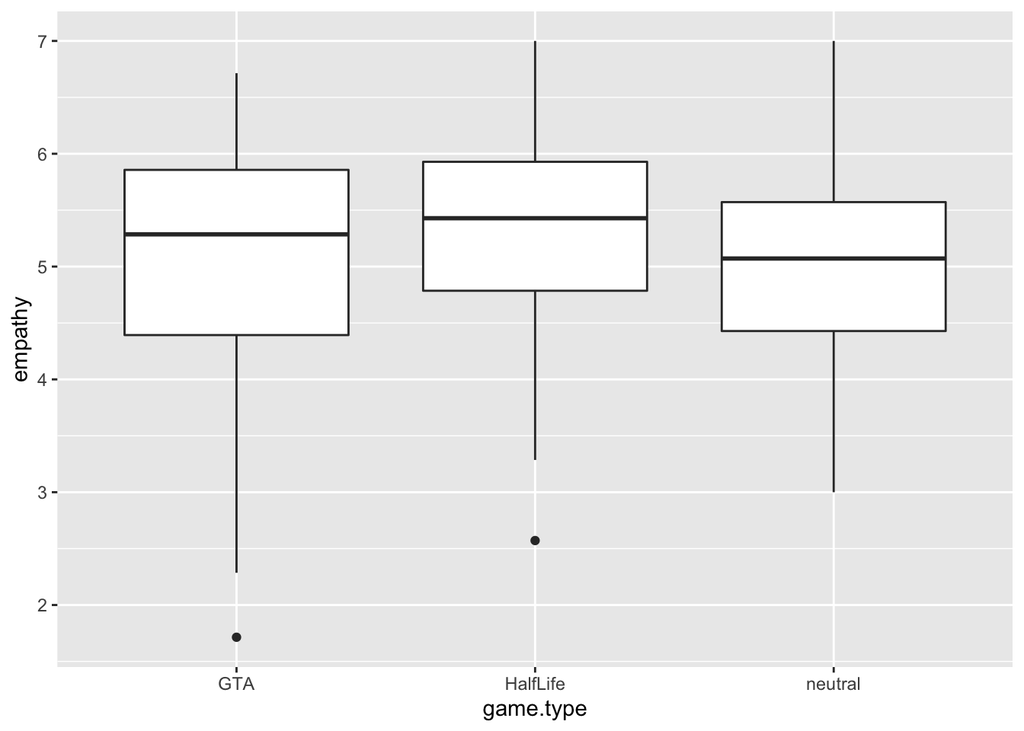

```r
ggplot(Game_empathy,aes(x = game.type, y = empathy))+ geom_boxplot()
```

```r
#The Mean empathy levels do look quite similar for the 3 game types. We'll test it formally using an anova test

Anova_test <- aov(empathy ~ game.type, data = Game_empathy)
summary(Anova_test)
```

```
##              Df Sum Sq Mean Sq F value Pr(>F)
## game.type     2   2.25   1.125   1.092  0.338
## Residuals   150 154.47   1.030
```

**With a high p-value of 0.338, we fail to reject the Null Hypothesis and can say that there is no real difference in average empathy levels of people playing various game types.**

**Answer 3:** Identificatin and empathy are both numeric variables. We can test relationship between 2 numeric variables using Pearson’s correlation.

**a)** The Null Hypothesis is that there is no relationship between identification and empathy levels for neutral players.

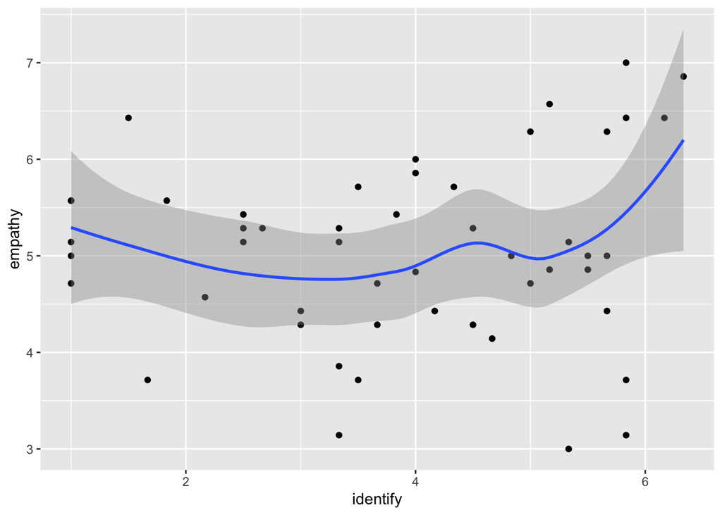

```r
neutral.players <- Game_empathy[Game_empathy$game.type == "neutral",]
ggplot(data = neutral.players, aes(x=identify,y=empathy))+geom_point()+geom_smooth()
```

```r
cor.test(neutral.players$identify,neutral.players$empathy)
```

```
##
##  Pearson's product-moment correlation
##
## data:  neutral.players$identify and neutral.players$empathy
## t = 0.62551, df = 48, p-value = 0.5346
## alternative hypothesis: true correlation is not equal to 0
## 95 percent confidence interval:
##  -0.1932661  0.3592743
## sample estimates:
##        cor
## 0.08991878
```

**With a large p-value of 0.5346, we fail to reject the null hypothesis and conclude that there is no correlation between identification and empathy for neutral players. We can see that the correlation comes out out to be a weak positive 0.08991878.**

**b)** The Null Hypothesis is that there is no relationship between identification and empathy levels for HalfLife players.

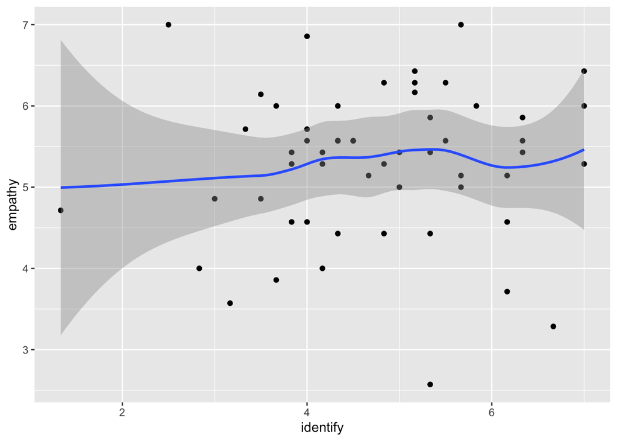

```r
HalfLife.players <- Game_empathy[Game_empathy$game.type == "HalfLife",]
ggplot(data = HalfLife.players, aes(x=identify,y=empathy))+geom_point()+geom_smooth()
```

```r
cor.test(HalfLife.players$identify,HalfLife.players$empathy)
```

```
##
##  Pearson's product-moment correlation
##
## data:  HalfLife.players$identify and HalfLife.players$empathy
## t = 0.52292, df = 53, p-value = 0.6032
## alternative hypothesis: true correlation is not equal to 0
## 95 percent confidence interval:
##  -0.1974049  0.3306568
## sample estimates:
##        cor
## 0.07164441
```

**With a large p-value of 0.6032, we fail to reject the null hypothesis and conclude that there is no correlation between identification and empathy for HalfLife players. We can see that the correlation comes out out to be a weak positive 0.07164441**

**c)** The Null Hypothesis is that there is no relationship between identification and empathy levels for GTA players. Remember that we are testing this null hypothesis at a significance level of 0.05

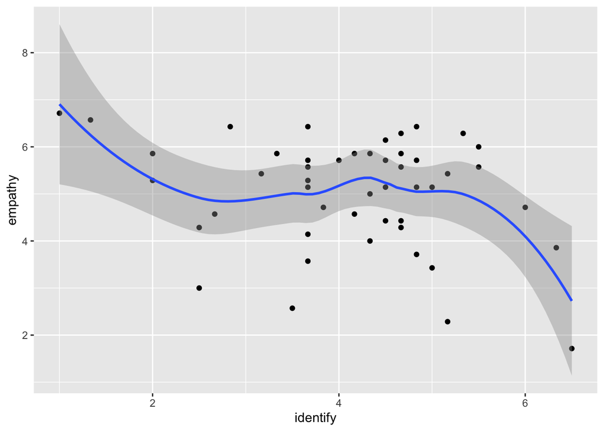

```r
GTA.players <- Game_empathy[Game_empathy$game.type == "GTA",]
ggplot(data = GTA.players, aes(x=identify,y=empathy))+geom_point()+geom_smooth()
```

```r
#There does seem to be a sort of negative relationship between empathy and identification from the graph.
cor.test(GTA.players$identify,GTA.players$empathy)
```

```
##
##  Pearson's product-moment correlation
##
## data:  GTA.players$identify and GTA.players$empathy
## t = -1.9192, df = 46, p-value = 0.06118
## alternative hypothesis: true correlation is not equal to 0
## 95 percent confidence interval:
##  -0.51645489  0.01285467
## sample estimates:
##        cor
## -0.2722745
```

**Question 4: a)** The present research shows that violent-sexist video games such as GTA reduce empathy for female violence victims, at least in the short-term.

**Ans 4 a):** It is mentioned nowehere in the data given, that the victim was a woman or a man. So this conclusion is not supported by the data given to us.

**Question 4: b)** This reduction in empathy partly occurs because video games such as GTA increase masculine beliefs, such as beliefs that “real men” are tough, dominant, and aggressive.

**Ans 4 b):** The data about masculine beliefs was not given to us. So this conclusion can also not be made by the data given to us.

**Question 4: c)** Our effects [i.e. the reductions in empathy due to violent-sexist video games] were especially pronounced among male participants who strongly identified with the misogynistic game characters.

**Ans 4 c):**

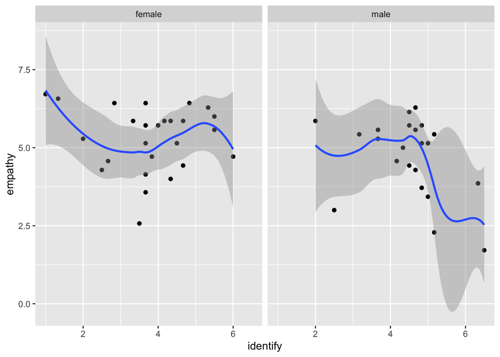

```r
#We may draw a scatter plot to see the rough relationship between empathy and identification with misogynistic character for males and females
ggplot(GTA.players,aes(x=identify, y=empathy))+ geom_point() + geom_smooth() + facet_grid(~sex)
```

```r
#From here we can see that the reduction in empathy levels for violence victims were particularly less for male victims as compared female victims and there does seem to be a negative correlation between identification with misogynistic character of males and reduction in empathy levels.

#We can do a correlation test on male and female players of GTA
Female.GTA.players <- GTA.players[GTA.players$sex == "female",]
cor.test(Female.GTA.players$identify,Female.GTA.players$empathy)
```

```
##
##  Pearson's product-moment correlation
##
## data:  Female.GTA.players$identify and Female.GTA.players$empathy
## t = -0.41713, df = 24, p-value = 0.6803
## alternative hypothesis: true correlation is not equal to 0
## 95 percent confidence interval:
##  -0.4571676  0.3127917
## sample estimates:
##         cor
## -0.08483937
```

```r
#There seems to be a weak negative correlation between Identification with misogynistic character and reduction in empathy levels.

Male.GTA.players <- GTA.players[GTA.players$sex == "male",]

cor.test(Male.GTA.players$identify,Male.GTA.players$empathy)
```

```
##
##  Pearson's product-moment correlation
##
## data:  Male.GTA.players$identify and Male.GTA.players$empathy
## t = -1.8166, df = 20, p-value = 0.08429
## alternative hypothesis: true correlation is not equal to 0
## 95 percent confidence interval:
##  -0.68868008  0.05380044
## sample estimates:
##        cor
## -0.3763445
```

**Here the correlation between Identification with misogynistic character and reduction in empathy levels is much higher at a negative 0.38. This means that males who do identify with misogynist characters show a reduction in empathy levels. Also this correlation is much stronger in men than women. But the p-value is again 0.08429. So we can’t reject the Null Hypothesis at this moment and would require more data to draw this conclusion. The sample size at the moment is just at a paultry 22(males) and 26(females)**